# Project: Identify Customer Segments

In this project, you will apply unsupervised learning techniques to identify segments of the population that form the core customer base for a mail-order sales company in Germany. These segments can then be used to direct marketing campaigns towards audiences that will have the highest expected rate of returns. The data that you will use has been provided by our partners at Bertelsmann Arvato Analytics, and represents a real-life data science task.

This notebook will help you complete this task by providing a framework within which you will perform your analysis steps. In each step of the project, you will see some text describing the subtask that you will perform, followed by one or more code cells for you to complete your work. **Feel free to add additional code and markdown cells as you go along so that you can explore everything in precise chunks.** The code cells provided in the base template will outline only the major tasks, and will usually not be enough to cover all of the minor tasks that comprise it.

It should be noted that while there will be precise guidelines on how you should handle certain tasks in the project, there will also be places where an exact specification is not provided. **There will be times in the project where you will need to make and justify your own decisions on how to treat the data.** These are places where there may not be only one way to handle the data. In real-life tasks, there may be many valid ways to approach an analysis task. One of the most important things you can do is clearly document your approach so that other scientists can understand the decisions you've made.

At the end of most sections, there will be a Markdown cell labeled **Discussion**. In these cells, you will report your findings for the completed section, as well as document the decisions that you made in your approach to each subtask. **Your project will be evaluated not just on the code used to complete the tasks outlined, but also your communication about your observations and conclusions at each stage.**

```python
# import libraries here; add more as necessary
import numpy as np
import pandas as pd
import matplotlib.pyplot as plt
import seaborn as sns

# magic word for producing visualizations in notebook
%matplotlib inline
sns.set()

from IPython.display import display
```

### Step 0: Load the Data

Each row of the demographics files represents a single person, but also includes information outside of individuals, including information about their household, building, and neighborhood. You will use this information to cluster the general population into groups with similar demographic properties. Then, you will see how the people in the customers dataset fit into those created clusters. The hope here is that certain clusters are over-represented in the customers data, as compared to the general population; those over-represented clusters will be assumed to be part of the core userbase. This information can then be used for further applications, such as targeting for a marketing campaign.

To start off with, load in the demographics data for the general population into a pandas DataFrame, and do the same for the feature attributes summary. Note for all of the `.csv` data files in this project: they're semicolon (`;`) delimited, so you'll need an additional argument in your [`read_csv()`](https://pandas.pydata.org/pandas-docs/stable/generated/pandas.read_csv.html) call to read in the data properly. Also, considering the size of the main dataset, it may take some time for it to load completely.

Once the dataset is loaded, it's recommended that you take a little bit of time just browsing the general structure of the dataset and feature summary file. You'll be getting deep into the innards of the cleaning in the first major step of the project, so gaining some general familiarity can help you get your bearings.

```python
# Load in the general demographics data.
azdias = pd.read_csv('Udacity_AZDIAS_Subset.csv', sep=';')

# Load in the feature summary file.
feat_info = pd.read_csv('AZDIAS_Feature_Summary.csv', sep=';')
```

```python
# make a copy of the general demographics dataset
azdias_copy = azdias.copy(deep=True)
```

```python
# Check the structure of the data after it's loaded (e.g. print the number of
# rows and columns, print the first few rows).

print('Udacity_AZDIAS_Subset')
print('{} rows and {} columns'.format(azdias.shape[0], azdias.shape[1]))
display(azdias.head(10))
```

```
Udacity_AZDIAS_Subset
891221 rows and 85 columns
```

|  | AGER_TYP | ALTERSKATEGORIE_GROB | ANREDE_KZ | CJT_GESAMTTYP | FINANZ_MINIMALIST | FINANZ_SPARER | FINANZ_VORSORGER | FINANZ_ANLEGER | FINANZ_UNAUFFAELLIGER | FINANZ_HAUSBAUER | ... | PLZ8_ANTG1 | PLZ8_ANTG2 | PLZ8_ANTG3 | PLZ8_ANTG4 | PLZ8_BAUMAX | PLZ8_HHZ | PLZ8_GBZ | ARBEIT | ORTSGR_KLS9 | RELAT_AB |
| --- | --- | --- | --- | --- | --- | --- | --- | --- | --- | --- | --- | --- | --- | --- | --- | --- | --- | --- | --- | --- | --- |
| 0 | -1 | 2 | 1 | 2.0 | 3 | 4 | 3 | 5 | 5 | 3 | ... | NaN | NaN | NaN | NaN | NaN | NaN | NaN | NaN | NaN | NaN |
| 1 | -1 | 1 | 2 | 5.0 | 1 | 5 | 2 | 5 | 4 | 5 | ... | 2.0 | 3.0 | 2.0 | 1.0 | 1.0 | 5.0 | 4.0 | 3.0 | 5.0 | 4.0 |
| 2 | -1 | 3 | 2 | 3.0 | 1 | 4 | 1 | 2 | 3 | 5 | ... | 3.0 | 3.0 | 1.0 | 0.0 | 1.0 | 4.0 | 4.0 | 3.0 | 5.0 | 2.0 |
| 3 | 2 | 4 | 2 | 2.0 | 4 | 2 | 5 | 2 | 1 | 2 | ... | 2.0 | 2.0 | 2.0 | 0.0 | 1.0 | 3.0 | 4.0 | 2.0 | 3.0 | 3.0 |
| 4 | -1 | 3 | 1 | 5.0 | 4 | 3 | 4 | 1 | 3 | 2 | ... | 2.0 | 4.0 | 2.0 | 1.0 | 2.0 | 3.0 | 3.0 | 4.0 | 6.0 | 5.0 |
| 5 | 3 | 1 | 2 | 2.0 | 3 | 1 | 5 | 2 | 2 | 5 | ... | 2.0 | 3.0 | 1.0 | 1.0 | 1.0 | 5.0 | 5.0 | 2.0 | 3.0 | 3.0 |
| 6 | -1 | 2 | 2 | 5.0 | 1 | 5 | 1 | 5 | 4 | 3 | ... | 3.0 | 3.0 | 1.0 | 0.0 | 1.0 | 5.0 | 5.0 | 4.0 | 6.0 | 3.0 |
| 7 | -1 | 1 | 1 | 3.0 | 3 | 3 | 4 | 1 | 3 | 2 | ... | 3.0 | 3.0 | 1.0 | 0.0 | 1.0 | 4.0 | 4.0 | 2.0 | 5.0 | 2.0 |
| 8 | -1 | 3 | 1 | 3.0 | 4 | 4 | 2 | 4 | 2 | 2 | ... | 2.0 | 3.0 | 2.0 | 1.0 | 1.0 | 3.0 | 3.0 | 2.0 | 4.0 | 3.0 |
| 9 | -1 | 3 | 2 | 4.0 | 2 | 4 | 2 | 3 | 5 | 4 | ... | 2.0 | 3.0 | 2.0 | 1.0 | 1.0 | 3.0 | 3.0 | 2.0 | 3.0 | 1.0 |

10 rows × 85 columns

```python
azdias.info()
```

```
<class 'pandas.core.frame.DataFrame'>
RangeIndex: 891221 entries, 0 to 891220
Data columns (total 85 columns):
AGER_TYP                 891221 non-null int64
ALTERSKATEGORIE_GROB     891221 non-null int64
ANREDE_KZ                891221 non-null int64
CJT_GESAMTTYP            886367 non-null float64
FINANZ_MINIMALIST        891221 non-null int64
FINANZ_SPARER            891221 non-null int64
FINANZ_VORSORGER         891221 non-null int64
FINANZ_ANLEGER           891221 non-null int64
FINANZ_UNAUFFAELLIGER    891221 non-null int64
FINANZ_HAUSBAUER         891221 non-null int64
FINANZTYP                891221 non-null int64
GEBURTSJAHR              891221 non-null int64
GFK_URLAUBERTYP          886367 non-null float64
GREEN_AVANTGARDE         891221 non-null int64
HEALTH_TYP               891221 non-null int64
LP_LEBENSPHASE_FEIN      886367 non-null float64
LP_LEBENSPHASE_GROB      886367 non-null float64
LP_FAMILIE_FEIN          886367 non-null float64
LP_FAMILIE_GROB          886367 non-null float64
LP_STATUS_FEIN           886367 non-null float64
LP_STATUS_GROB           886367 non-null float64
NATIONALITAET_KZ         891221 non-null int64
PRAEGENDE_JUGENDJAHRE    891221 non-null int64
RETOURTYP_BK_S           886367 non-null float64
SEMIO_SOZ                891221 non-null int64
SEMIO_FAM                891221 non-null int64
SEMIO_REL                891221 non-null int64
SEMIO_MAT                891221 non-null int64
SEMIO_VERT               891221 non-null int64
SEMIO_LUST               891221 non-null int64
SEMIO_ERL                891221 non-null int64
SEMIO_KULT               891221 non-null int64
SEMIO_RAT                891221 non-null int64
SEMIO_KRIT               891221 non-null int64
SEMIO_DOM                891221 non-null int64
SEMIO_KAEM               891221 non-null int64
SEMIO_PFLICHT            891221 non-null int64
```

[output cut: 35 more lines]

```
ONLINE_AFFINITAET        886367 non-null float64
REGIOTYP                 770025 non-null float64
KBA13_ANZAHL_PKW         785421 non-null float64
PLZ8_ANTG1               774706 non-null float64
PLZ8_ANTG2               774706 non-null float64
PLZ8_ANTG3               774706 non-null float64
PLZ8_ANTG4               774706 non-null float64
PLZ8_BAUMAX              774706 non-null float64
PLZ8_HHZ                 774706 non-null float64
PLZ8_GBZ                 774706 non-null float64
ARBEIT                   794005 non-null float64
ORTSGR_KLS9              794005 non-null float64
RELAT_AB                 794005 non-null float64
dtypes: float64(49), int64(32), object(4)
memory usage: 578.0+ MB
```

```python
print('AZDIAS_Feature_Summary')
print('{} rows and {} columns'.format(feat_info.shape[0], feat_info.shape[1]))
display(feat_info.head())
```

```
AZDIAS_Feature_Summary
85 rows and 4 columns
```

|  | attribute | information_level | type | missing_or_unknown |
| --- | --- | --- | --- | --- |
| 0 | AGER_TYP | person | categorical | [-1,0] |
| 1 | ALTERSKATEGORIE_GROB | person | ordinal | [-1,0,9] |
| 2 | ANREDE_KZ | person | categorical | [-1,0] |
| 3 | CJT_GESAMTTYP | person | categorical | [0] |
| 4 | FINANZ_MINIMALIST | person | ordinal | [-1] |

> **Tip**: Add additional cells to keep everything in reasonably-sized chunks! Keyboard shortcut `esc --> a` (press escape to enter command mode, then press the 'A' key) adds a new cell before the active cell, and `esc --> b` adds a new cell after the active cell. If you need to convert an active cell to a markdown cell, use `esc --> m` and to convert to a code cell, use `esc --> y`.

## Step 1: Preprocessing

### Step 1.1: Assess Missing Data

The feature summary file contains a summary of properties for each demographics data column. You will use this file to help you make cleaning decisions during this stage of the project. First of all, you should assess the demographics data in terms of missing data. Pay attention to the following points as you perform your analysis, and take notes on what you observe. Make sure that you fill in the **Discussion** cell with your findings and decisions at the end of each step that has one!

#### Step 1.1.1: Convert Missing Value Codes to NaNs

The fourth column of the feature attributes summary (loaded in above as `feat_info`) documents the codes from the data dictionary that indicate missing or unknown data. While the file encodes this as a list (e.g. `[-1,0]`), this will get read in as a string object. You'll need to do a little bit of parsing to make use of it to identify and clean the data. Convert data that matches a 'missing' or 'unknown' value code into a numpy NaN value. You might want to see how much data takes on a 'missing' or 'unknown' code, and how much data is naturally missing, as a point of interest.

**As one more reminder, you are encouraged to add additional cells to break up your analysis into manageable chunks.**

```python
# Identify missing or unknown data values and convert them to NaNs.
```

```python
# First preprocess feature summary data
feat_info_cp = feat_info.copy(deep=True)
```

```python
remove_brackets = lambda s : s.strip('[]')
```

```python
feat_info.missing_or_unknown = feat_info.missing_or_unknown.apply(remove_brackets)
display(feat_info.head())
```

|  | attribute | information_level | type | missing_or_unknown |
| --- | --- | --- | --- | --- |
| 0 | AGER_TYP | person | categorical | -1,0 |
| 1 | ALTERSKATEGORIE_GROB | person | ordinal | -1,0,9 |
| 2 | ANREDE_KZ | person | categorical | -1,0 |
| 3 | CJT_GESAMTTYP | person | categorical | 0 |
| 4 | FINANZ_MINIMALIST | person | ordinal | -1 |

```python
feat_info.info()
```

```
<class 'pandas.core.frame.DataFrame'>
RangeIndex: 85 entries, 0 to 84
Data columns (total 4 columns):
attribute             85 non-null object
information_level     85 non-null object
type                  85 non-null object
missing_or_unknown    85 non-null object
dtypes: object(4)
memory usage: 2.7+ KB
```

```python
# Datatype and naturally missing values in original data

data_dict = {}

for col in azdias.columns:
    data_dict[col] = {'datatype': azdias[col].dtype, 'init_missing': azdias[col].isnull().sum()}
```

```python
# Convert missing value codes to NaN
for col in azdias.columns:
    missing_value_codes = feat_info[feat_info.attribute == col]['missing_or_unknown'].values[0].split(',')
    if len(missing_value_codes[0]) != 0:
        for idx in range(len(missing_value_codes)):
            try:
                missing_value_codes[idx] = int(missing_value_codes[idx])
            except:
                pass
        azdias[col].replace(missing_value_codes, np.NaN, inplace=True)
```

```python
display(azdias.head())
```

|  | AGER_TYP | ALTERSKATEGORIE_GROB | ANREDE_KZ | CJT_GESAMTTYP | FINANZ_MINIMALIST | FINANZ_SPARER | FINANZ_VORSORGER | FINANZ_ANLEGER | FINANZ_UNAUFFAELLIGER | FINANZ_HAUSBAUER | ... | PLZ8_ANTG1 | PLZ8_ANTG2 | PLZ8_ANTG3 | PLZ8_ANTG4 | PLZ8_BAUMAX | PLZ8_HHZ | PLZ8_GBZ | ARBEIT | ORTSGR_KLS9 | RELAT_AB |
| --- | --- | --- | --- | --- | --- | --- | --- | --- | --- | --- | --- | --- | --- | --- | --- | --- | --- | --- | --- | --- | --- |
| 0 | NaN | 2.0 | 1 | 2.0 | 3 | 4 | 3 | 5 | 5 | 3 | ... | NaN | NaN | NaN | NaN | NaN | NaN | NaN | NaN | NaN | NaN |
| 1 | NaN | 1.0 | 2 | 5.0 | 1 | 5 | 2 | 5 | 4 | 5 | ... | 2.0 | 3.0 | 2.0 | 1.0 | 1.0 | 5.0 | 4.0 | 3.0 | 5.0 | 4.0 |
| 2 | NaN | 3.0 | 2 | 3.0 | 1 | 4 | 1 | 2 | 3 | 5 | ... | 3.0 | 3.0 | 1.0 | 0.0 | 1.0 | 4.0 | 4.0 | 3.0 | 5.0 | 2.0 |
| 3 | 2.0 | 4.0 | 2 | 2.0 | 4 | 2 | 5 | 2 | 1 | 2 | ... | 2.0 | 2.0 | 2.0 | 0.0 | 1.0 | 3.0 | 4.0 | 2.0 | 3.0 | 3.0 |
| 4 | NaN | 3.0 | 1 | 5.0 | 4 | 3 | 4 | 1 | 3 | 2 | ... | 2.0 | 4.0 | 2.0 | 1.0 | 2.0 | 3.0 | 3.0 | 4.0 | 6.0 | 5.0 |

5 rows × 85 columns

#### Step 1.1.2: Assess Missing Data in Each Column

How much missing data is present in each column? There are a few columns that are outliers in terms of the proportion of values that are missing. You will want to use matplotlib's [`hist()`](https://matplotlib.org/api/_as_gen/matplotlib.pyplot.hist.html) function to visualize the distribution of missing value counts to find these columns. Identify and document these columns. While some of these columns might have justifications for keeping or re-encoding the data, for this project you should just remove them from the dataframe. (Feel free to make remarks about these outlier columns in the discussion, however!)

For the remaining features, are there any patterns in which columns have, or share, missing data?

```python
# Perform an assessment of how much missing data there is in each column of the
# dataset.

for col in azdias.columns:
    data_dict[col]['missing'] = azdias[col].isnull().sum()

data_info = pd.DataFrame(data_dict).transpose()

data_info[data_info['init_missing'] < data_info['missing']]
```

|  | datatype | init_missing | missing |
| --- | --- | --- | --- |
| AGER_TYP | int64 | 0 | 685843 |
| ALTERSKATEGORIE_GROB | int64 | 0 | 2881 |
| ALTER_HH | float64 | 73499 | 310267 |
| ANZ_HAUSHALTE_AKTIV | float64 | 93148 | 99611 |
| ARBEIT | float64 | 97216 | 97375 |
| CAMEO_DEUG_2015 | object | 98979 | 99352 |
| CAMEO_DEU_2015 | object | 98979 | 99352 |
| CAMEO_INTL_2015 | object | 98979 | 99352 |
| GEBURTSJAHR | int64 | 0 | 392318 |
| HEALTH_TYP | int64 | 0 | 111196 |
| KBA05_BAUMAX | float64 | 133324 | 476524 |
| KKK | float64 | 121196 | 158064 |
| LP_FAMILIE_FEIN | float64 | 4854 | 77792 |
| LP_FAMILIE_GROB | float64 | 4854 | 77792 |
| LP_LEBENSPHASE_FEIN | float64 | 4854 | 97632 |
| LP_LEBENSPHASE_GROB | float64 | 4854 | 94572 |
| NATIONALITAET_KZ | int64 | 0 | 108315 |
| ORTSGR_KLS9 | float64 | 97216 | 97274 |
| PRAEGENDE_JUGENDJAHRE | int64 | 0 | 108164 |
| REGIOTYP | float64 | 121196 | 158064 |
| RELAT_AB | float64 | 97216 | 97375 |
| SHOPPER_TYP | int64 | 0 | 111196 |
| TITEL_KZ | float64 | 73499 | 889061 |
| VERS_TYP | int64 | 0 | 111196 |
| W_KEIT_KIND_HH | float64 | 107602 | 147988 |

*Lot of missing values were captured as codes (missing / unknown values). This should be properly handled, else it would affect our analysis.*

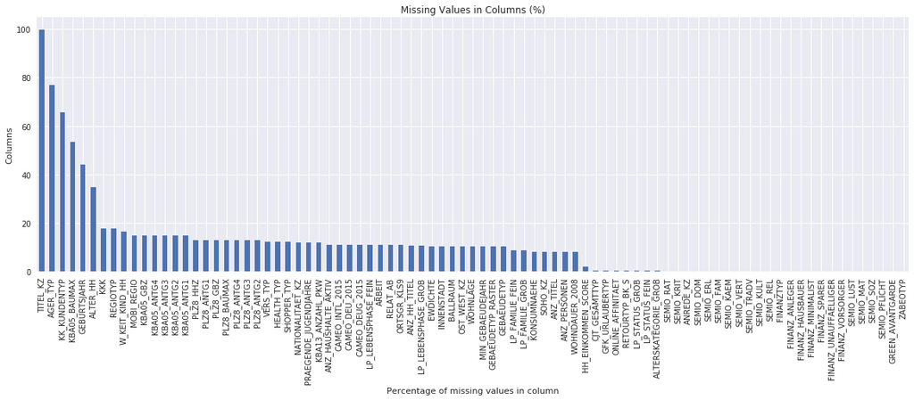

```python
total_records = azdias.shape[0]
data_info['percentage_missing'] = data_info['missing'].apply(lambda x : round((x/total_records)*100, 2))
missing_percents = data_info['percentage_missing'].sort_values(ascending=False)

fig = plt.figure(figsize=(20,6))
missing_percents.plot(kind='bar')
plt.xlabel('Percentage of missing values in column')
plt.ylabel('Columns')
plt.title('Missing Values in Columns (%)')
plt.show()
```

```python
# Investigate patterns in the amount of missing data in each column.
print('% Missing \t Columns')
print('------------------------')
missing_groups = {str(t):list(missing_percents[missing_percents==t].index) for t in missing_percents.unique()}
for key in missing_groups.keys():
    print(key, '\t \t', missing_groups[key])
```

[output not shown]

```python
# Remove the outlier columns from the dataset. (You'll perform other data
# engineering tasks such as re-encoding and imputation later.)

columns_to_remove = ['TITEL_KZ','AGER_TYP','KK_KUNDENTYP','KBA05_BAUMAX','GEBURTSJAHR','ALTER_HH']

azdias.drop(columns_to_remove, axis=1, inplace=True)

azdias.shape
```

```
(891221, 79)
```

```python
azdias.to_csv('azdias_dropped_columns.csv', index=False)
```

#### Discussion 1.1.2: Assess Missing Data in Each Column

(Double click this cell and replace this text with your own text, reporting your observations regarding the amount of missing data in each column. Are there any patterns in missing values? Which columns were removed from the dataset?)

We can see 3 groups of columns in terms of missing values (NaNs).

- 1 group : <10% missing
- 2 group : 10 - 30% missing
- 3 group : >30% missing

Features in the first group describe personal information such as gender (ANREDE_KZ), financial information (FINANZ_MINIMALIST), family and household information, and people's behavior(online affinity, buying channel, return type) etc... These are prominient features and it is great that they contain only few values missing values.

The second group focuses more on household, neighbourhood and region information. It makes sense that this group contains more missing values since some of these features are hard to collect in a survey or census.

The third and most important group has more than 30% missing values.

- **TITEL_KZ** : Academic title flag
- **AGER_TYP** : Best-ager typology
- **KK_KUNDENTYP** : Consumer pattern over past 12 months
- **KBA05_BAUMAX** : Most common building type within the microcell
- **GEBURTSJAHR** : Year of birth
- **ALTER_HH** : Birthdate of head of household

All the 6 features in the third group are dropped since we have a lot of missing values in them. I think features like Academic Title, Common building type, Birthdate of household head are not really important for our task, so we can safely ignore them. Since there are other features to describe age, we can ignore year of birth and best-ager topology too. Still year of birth could have been the best determiner for age. Finally, its disappointing to see lot of missing values in consumer pattern feature. It is the most relevant field and if we could engineer and use it in anyway, we should. But for the scope of this project, it is being dropped.

#### Step 1.1.3: Assess Missing Data in Each Row

Now, you'll perform a similar assessment for the rows of the dataset. How much data is missing in each row? As with the columns, you should see some groups of points that have a very different numbers of missing values. Divide the data into two subsets: one for data points that are above some threshold for missing values, and a second subset for points below that threshold.

In order to know what to do with the outlier rows, we should see if the distribution of data values on columns that are not missing data (or are missing very little data) are similar or different between the two groups. Select at least five of these columns and compare the distribution of values.

- You can use seaborn's [`countplot()`](https://seaborn.pydata.org/generated/seaborn.countplot.html) function to create a bar chart of code frequencies and matplotlib's [`subplot()`](https://matplotlib.org/api/_as_gen/matplotlib.pyplot.subplot.html) function to put bar charts for the two subplots side by side.
- To reduce repeated code, you might want to write a function that can perform this comparison, taking as one of its arguments a column to be compared.

Depending on what you observe in your comparison, this will have implications on how you approach your conclusions later in the analysis. If the distributions of non-missing features look similar between the data with many missing values and the data with few or no missing values, then we could argue that simply dropping those points from the analysis won't present a major issue. On the other hand, if the data with many missing values looks very different from the data with few or no missing values, then we should make a note on those data as special. We'll revisit these data later on. **Either way, you should continue your analysis for now using just the subset of the data with few or no missing values.**

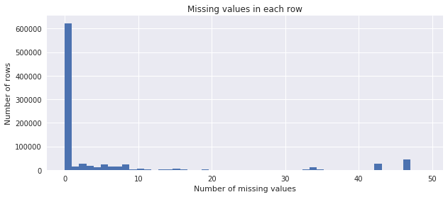

```python
# How much data is missing in each row of the dataset?

missing_each_row = (azdias.isnull()).sum(axis=1)

fig = plt.figure(figsize=(10,4))
missing_each_row.hist(bins=50)
plt.title('Missing values in each row');
plt.xlabel('Number of missing values');
plt.ylabel('Number of rows');
plt.show()
```

```python
# Write code to divide the data into two subsets based on the number of missing
# values in each row.

# threshold 10
azdias_inliers = azdias[missing_each_row <= 10]
azdias_outliers = azdias[missing_each_row > 10]
```

```python
azdias_inliers.head()
```

|  | ALTERSKATEGORIE_GROB | ANREDE_KZ | CJT_GESAMTTYP | FINANZ_MINIMALIST | FINANZ_SPARER | FINANZ_VORSORGER | FINANZ_ANLEGER | FINANZ_UNAUFFAELLIGER | FINANZ_HAUSBAUER | FINANZTYP | ... | PLZ8_ANTG1 | PLZ8_ANTG2 | PLZ8_ANTG3 | PLZ8_ANTG4 | PLZ8_BAUMAX | PLZ8_HHZ | PLZ8_GBZ | ARBEIT | ORTSGR_KLS9 | RELAT_AB |
| --- | --- | --- | --- | --- | --- | --- | --- | --- | --- | --- | --- | --- | --- | --- | --- | --- | --- | --- | --- | --- | --- |
| 1 | 1.0 | 2 | 5.0 | 1 | 5 | 2 | 5 | 4 | 5 | 1 | ... | 2.0 | 3.0 | 2.0 | 1.0 | 1.0 | 5.0 | 4.0 | 3.0 | 5.0 | 4.0 |
| 2 | 3.0 | 2 | 3.0 | 1 | 4 | 1 | 2 | 3 | 5 | 1 | ... | 3.0 | 3.0 | 1.0 | 0.0 | 1.0 | 4.0 | 4.0 | 3.0 | 5.0 | 2.0 |
| 3 | 4.0 | 2 | 2.0 | 4 | 2 | 5 | 2 | 1 | 2 | 6 | ... | 2.0 | 2.0 | 2.0 | 0.0 | 1.0 | 3.0 | 4.0 | 2.0 | 3.0 | 3.0 |
| 4 | 3.0 | 1 | 5.0 | 4 | 3 | 4 | 1 | 3 | 2 | 5 | ... | 2.0 | 4.0 | 2.0 | 1.0 | 2.0 | 3.0 | 3.0 | 4.0 | 6.0 | 5.0 |
| 5 | 1.0 | 2 | 2.0 | 3 | 1 | 5 | 2 | 2 | 5 | 2 | ... | 2.0 | 3.0 | 1.0 | 1.0 | 1.0 | 5.0 | 5.0 | 2.0 | 3.0 | 3.0 |

5 rows × 79 columns

```python
azdias_outliers.head()
```

|  | ALTERSKATEGORIE_GROB | ANREDE_KZ | CJT_GESAMTTYP | FINANZ_MINIMALIST | FINANZ_SPARER | FINANZ_VORSORGER | FINANZ_ANLEGER | FINANZ_UNAUFFAELLIGER | FINANZ_HAUSBAUER | FINANZTYP | ... | PLZ8_ANTG1 | PLZ8_ANTG2 | PLZ8_ANTG3 | PLZ8_ANTG4 | PLZ8_BAUMAX | PLZ8_HHZ | PLZ8_GBZ | ARBEIT | ORTSGR_KLS9 | RELAT_AB |
| --- | --- | --- | --- | --- | --- | --- | --- | --- | --- | --- | --- | --- | --- | --- | --- | --- | --- | --- | --- | --- | --- |
| 0 | 2.0 | 1 | 2.0 | 3 | 4 | 3 | 5 | 5 | 3 | 4 | ... | NaN | NaN | NaN | NaN | NaN | NaN | NaN | NaN | NaN | NaN |
| 11 | 2.0 | 1 | 6.0 | 3 | 4 | 3 | 5 | 5 | 3 | 4 | ... | NaN | NaN | NaN | NaN | NaN | NaN | NaN | NaN | NaN | NaN |
| 14 | 3.0 | 1 | 6.0 | 3 | 4 | 3 | 5 | 5 | 3 | 4 | ... | NaN | NaN | NaN | NaN | NaN | NaN | NaN | NaN | NaN | NaN |
| 17 | 2.0 | 1 | 6.0 | 3 | 4 | 3 | 5 | 5 | 3 | 4 | ... | NaN | NaN | NaN | NaN | NaN | NaN | NaN | NaN | NaN | NaN |
| 24 | 3.0 | 2 | 6.0 | 3 | 4 | 3 | 5 | 5 | 3 | 4 | ... | NaN | NaN | NaN | NaN | NaN | NaN | NaN | NaN | NaN | NaN |

5 rows × 79 columns

```python
# Compare the distribution of values for at least five columns where there are
# no or few missing values, between the two subsets.

columns_picked = ['ALTERSKATEGORIE_GROB', 'ANREDE_KZ', 'FINANZ_MINIMALIST', 'PLZ8_HHZ', 'PLZ8_GBZ']
```

```python
def compare_dist(col):
    plt.figure(figsize=(10, 4))
    ax1 = plt.subplot(1, 2, 1)
    sns.countplot(x=col, data=azdias_inliers)
    plt.title('Inliers (clean)')
    plt.ylabel('count')
    ax2 = plt.subplot(1, 2, 2) # , sharey=ax1)
    sns.countplot(x=col, data=azdias_outliers)
    plt.title('Outliers (missing)')
    plt.ylabel('count')
    plt.suptitle(col)
    plt.show();
```

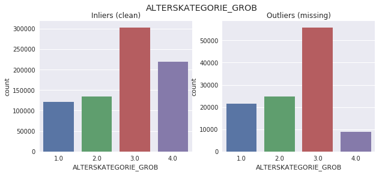

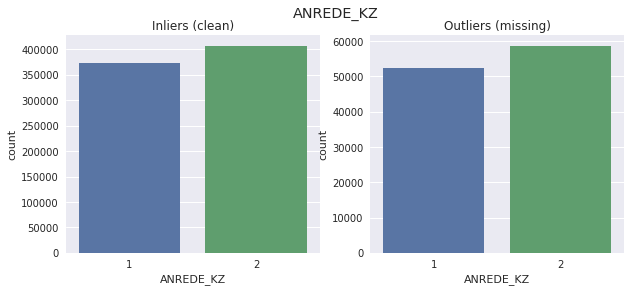

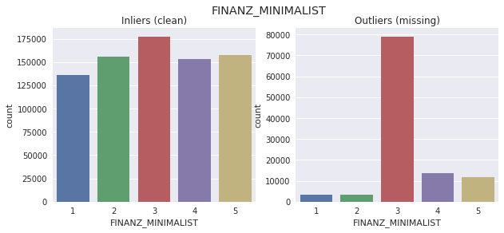

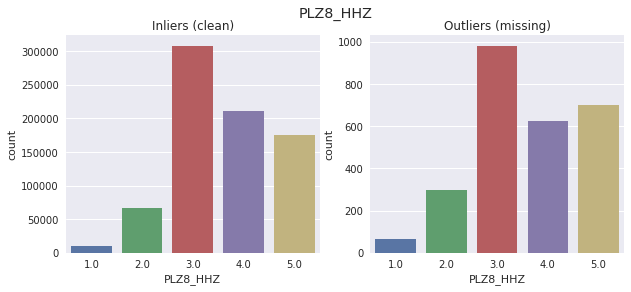

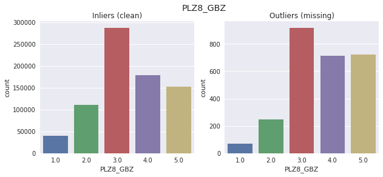

```python
for col in columns_picked:
    compare_dist(col)
```

```python
# drop outlier rows
azdias = azdias_inliers.copy(deep=True)
```

#### Discussion 1.1.3: Assess Missing Data in Each Row

(Double-click this cell and replace this text with your own text, reporting your observations regarding missing data in rows. Are the data with lots of missing values are qualitatively different from data with few or no missing values?)

We can consider two groups here, setting the threshold of missing values at 10.

- Missing values <=10
- Missing values >10

The first group of data is qualitatively better than the second.

But we are focused on the distribution of values between 2 subsets of data (inliers and outliers), so we can group features into the following categories.

1. Similar distribution  
   e.g. ANREDE_KZ
2. One value is different  
   e.g. ALTERSKATEGORIE_GROB
3. Lot of values are different. i.e. NaNs are dominant  
   e.g. FINANZ_MINIMALIST

I dropped the outliers with >10 missing values since they have a large number of NaNs in each row. Though the distribution of data is different, for the scope of this project only the inliers data is considered where the characteristics of data is captured qualitatively better.

### Step 1.2: Select and Re-Encode Features

Checking for missing data isn't the only way in which you can prepare a dataset for analysis. Since the unsupervised learning techniques to be used will only work on data that is encoded numerically, you need to make a few encoding changes or additional assumptions to be able to make progress. In addition, while almost all of the values in the dataset are encoded using numbers, not all of them represent numeric values. Check the third column of the feature summary (`feat_info`) for a summary of types of measurement.

- For numeric and interval data, these features can be kept without changes.
- Most of the variables in the dataset are ordinal in nature. While ordinal values may technically be non-linear in spacing, make the simplifying assumption that the ordinal variables can be treated as being interval in nature (that is, kept without any changes).
- Special handling may be necessary for the remaining two variable types: categorical, and 'mixed'.

In the first two parts of this sub-step, you will perform an investigation of the categorical and mixed-type features and make a decision on each of them, whether you will keep, drop, or re-encode each. Then, in the last part, you will create a new data frame with only the selected and engineered columns.

Data wrangling is often the trickiest part of the data analysis process, and there's a lot of it to be done here. But stick with it: once you're done with this step, you'll be ready to get to the machine learning parts of the project!

```python
# How many features are there of each data type?

feat_info['type'].value_counts()
```

```
ordinal        49
categorical    21
numeric         7
mixed           7
interval        1
Name: type, dtype: int64
```

```python
feat_info.head(2)
```

|  | attribute | information_level | type | missing_or_unknown |
| --- | --- | --- | --- | --- |
| 0 | AGER_TYP | person | categorical | -1,0 |
| 1 | ALTERSKATEGORIE_GROB | person | ordinal | -1,0,9 |

```python
ordinal_features = list(feat_info[feat_info['type'] == 'ordinal']['attribute'])
categorical_features = list(feat_info[feat_info['type'] == 'categorical']['attribute'])
numeric_features = list(feat_info[feat_info['type'] == 'numeric']['attribute'])
mixed_features = list(feat_info[feat_info['type'] == 'mixed']['attribute'])
interval_features = list(feat_info[feat_info['type'] == 'interval']['attribute'])
```

```python
ordinal_features = [col for col in ordinal_features if col in azdias.columns]
categorical_features = [col for col in categorical_features if col in azdias.columns]
numeric_features = [col for col in numeric_features if col in azdias.columns]
mixed_features = [col for col in mixed_features if col in azdias.columns]
interval_features = [col for col in interval_features if col in azdias.columns]
```

```python
print(len(azdias.columns))
print(len(ordinal_features)+len(categorical_features)+len(numeric_features)+len(mixed_features)+len(interval_features))
```

```
79
79
```

#### Step 1.2.1: Re-Encode Categorical Features

For categorical data, you would ordinarily need to encode the levels as dummy variables. Depending on the number of categories, perform one of the following:

- For binary (two-level) categoricals that take numeric values, you can keep them without needing to do anything.
- There is one binary variable that takes on non-numeric values. For this one, you need to re-encode the values as numbers or create a dummy variable.
- For multi-level categoricals (three or more values), you can choose to encode the values using multiple dummy variables (e.g. via [OneHotEncoder](http://scikit-learn.org/stable/modules/generated/sklearn.preprocessing.OneHotEncoder.html)), or (to keep things straightforward) just drop them from the analysis. As always, document your choices in the Discussion section.

```python
# Assess categorical variables: which are binary, which are multi-level, and
# which one needs to be re-encoded?
```

```python
print('Total number of categorical features : {}'.format(len(categorical_features)))
```

```
Total number of categorical features : 18
```

**Binary features**

```python
binary_features = [col for col in categorical_features if azdias[col].nunique() == 2]
binary_features
```

```
['ANREDE_KZ', 'GREEN_AVANTGARDE', 'SOHO_KZ', 'VERS_TYP', 'OST_WEST_KZ']
```

```python
# binary feature to be re-encoded
binary_temp = [col for col in binary_features if azdias[col].dtype == object][0]
binary_temp
```

```
'OST_WEST_KZ'
```

```python
azdias[binary_temp].unique()
```

```
array(['W', 'O'], dtype=object)
```

```python
encoding_map = {'O': 0, 'W': 1}
azdias.replace({'OST_WEST_KZ': encoding_map}, inplace=True)
```

```python
azdias_binary = pd.DataFrame({col:azdias[col] for col in binary_features})
azdias_binary.head()
```

|  | ANREDE_KZ | GREEN_AVANTGARDE | OST_WEST_KZ | SOHO_KZ | VERS_TYP |
| --- | --- | --- | --- | --- | --- |
| 1 | 2 | 0 | 1 | 1.0 | 2.0 |
| 2 | 2 | 1 | 1 | 0.0 | 1.0 |
| 3 | 2 | 0 | 1 | 0.0 | 1.0 |
| 4 | 1 | 0 | 1 | 0.0 | 2.0 |
| 5 | 2 | 0 | 1 | 0.0 | 2.0 |

```python
azdias_binary.info()
```

```
<class 'pandas.core.frame.DataFrame'>
Int64Index: 780153 entries, 1 to 891220
Data columns (total 5 columns):
ANREDE_KZ           780153 non-null int64
GREEN_AVANTGARDE    780153 non-null int64
OST_WEST_KZ         780153 non-null int64
SOHO_KZ             780153 non-null float64
VERS_TYP            745629 non-null float64
dtypes: float64(2), int64(3)
memory usage: 35.7 MB
```

**Multi-level Categorical features**

```python
# Re-encode categorical variable(s) to be kept in the analysis.
```

```python
multi_categorical = [col for col in categorical_features if col not in binary_features]
```

```python
azdias_categorical = pd.get_dummies(azdias[multi_categorical].astype(np.object))

azdias_categorical.head()
```

|  | CJT_GESAMTTYP_1.0 | CJT_GESAMTTYP_2.0 | CJT_GESAMTTYP_3.0 | CJT_GESAMTTYP_4.0 | CJT_GESAMTTYP_5.0 | CJT_GESAMTTYP_6.0 | FINANZTYP_1 | FINANZTYP_2 | FINANZTYP_3 | FINANZTYP_4 | ... | CAMEO_DEU_2015_7E | CAMEO_DEU_2015_8A | CAMEO_DEU_2015_8B | CAMEO_DEU_2015_8C | CAMEO_DEU_2015_8D | CAMEO_DEU_2015_9A | CAMEO_DEU_2015_9B | CAMEO_DEU_2015_9C | CAMEO_DEU_2015_9D | CAMEO_DEU_2015_9E |
| --- | --- | --- | --- | --- | --- | --- | --- | --- | --- | --- | --- | --- | --- | --- | --- | --- | --- | --- | --- | --- | --- |
| 1 | 0 | 0 | 0 | 0 | 1 | 0 | 1 | 0 | 0 | 0 | ... | 0 | 1 | 0 | 0 | 0 | 0 | 0 | 0 | 0 | 0 |
| 2 | 0 | 0 | 1 | 0 | 0 | 0 | 1 | 0 | 0 | 0 | ... | 0 | 0 | 0 | 0 | 0 | 0 | 0 | 0 | 0 | 0 |
| 3 | 0 | 1 | 0 | 0 | 0 | 0 | 0 | 0 | 0 | 0 | ... | 0 | 0 | 0 | 0 | 0 | 0 | 0 | 0 | 0 | 0 |
| 4 | 0 | 0 | 0 | 0 | 1 | 0 | 0 | 0 | 0 | 0 | ... | 0 | 0 | 0 | 0 | 0 | 0 | 0 | 0 | 0 | 0 |
| 5 | 0 | 1 | 0 | 0 | 0 | 0 | 0 | 1 | 0 | 0 | ... | 0 | 0 | 0 | 1 | 0 | 0 | 0 | 0 | 0 | 0 |

5 rows × 128 columns

```python
for col in azdias_categorical.columns:
    if not pd.api.types.is_numeric_dtype(azdias_categorical[col]):
        raise ValueError("{} is not numeric dtype".format(col))
```

#### Discussion 1.2.1: Re-Encode Categorical Features

(Double-click this cell and replace this text with your own text, reporting your findings and decisions regarding categorical features. Which ones did you keep, which did you drop, and what engineering steps did you perform?)

- Re-coded 'OST_WEST_KZ' binary feature
- Endoded all the multi-level categorical features as one-hot encoded features using pandas 'get_dummies' function
- No feature was dropped

#### Step 1.2.2: Engineer Mixed-Type Features

There are a handful of features that are marked as "mixed" in the feature summary that require special treatment in order to be included in the analysis. There are two in particular that deserve attention; the handling of the rest are up to your own choices:

- "PRAEGENDE_JUGENDJAHRE" combines information on three dimensions: generation by decade, movement (mainstream vs. avantgarde), and nation (east vs. west). While there aren't enough levels to disentangle east from west, you should create two new variables to capture the other two dimensions: an interval-type variable for decade, and a binary variable for movement.
- "CAMEO_INTL_2015" combines information on two axes: wealth and life stage. Break up the two-digit codes by their 'tens'-place and 'ones'-place digits into two new ordinal variables (which, for the purposes of this project, is equivalent to just treating them as their raw numeric values).
- If you decide to keep or engineer new features around the other mixed-type features, make sure you note your steps in the Discussion section.

Be sure to check `Data_Dictionary.md` for the details needed to finish these tasks.

```python
print(mixed_features)
```

```
['LP_LEBENSPHASE_FEIN', 'LP_LEBENSPHASE_GROB', 'PRAEGENDE_JUGENDJAHRE', 'WOHNLAGE', 'CAMEO_INTL_2015', 'PLZ8_BAUMAX']
```

```python
azdias['PRAEGENDE_JUGENDJAHRE'].unique()
```

```
array([ 14.,  15.,   8.,   3.,  10.,  11.,   5.,   9.,   6.,   4.,  nan,
         2.,   1.,  12.,  13.,   7.])
```

```python
# Investigate "PRAEGENDE_JUGENDJAHRE" and engineer two new variables.

# Decade : interval type. 40s: 1, 50s: 2, 60s: 3, 70s: 4, 80s: 5, 90s: 6
PRAEGENDE_JUGENDJAHR_DECADE = azdias['PRAEGENDE_JUGENDJAHRE'].replace({
    1.0: 1, 2.0: 1, 3.0: 2, 4.0: 2, 5.0: 3, 6.0: 3, 7.0: 3,
    8.0: 4, 9.0: 4, 10.0: 5, 11.0: 5, 12.0: 5, 13.0: 5,
    14.0: 6, 15.0: 6 })

# Movement : binary type. Mainstream: 0, Avantgarde: 1
PRAEGENDE_JUGENDJAHRE_MOVEMENT = azdias['PRAEGENDE_JUGENDJAHRE'].replace({
    1.0: 0, 2.0: 1, 3.0: 0, 4.0: 1, 5.0: 0, 6.0: 1, 7.0: 1,
    8.0: 0, 9.0: 1, 10.0: 0, 11.0: 1, 12.0: 0, 13.0: 1,
    14.0: 0, 15.0: 1 })


azdias_mixed_categorical = pd.DataFrame({
    'PRAEGENDE_JUGENDJAHR_DECADE': PRAEGENDE_JUGENDJAHR_DECADE,
    'PRAEGENDE_JUGENDJAHRE_MOVEMENT': PRAEGENDE_JUGENDJAHRE_MOVEMENT
})
```

```python
# Investigate "CAMEO_INTL_2015" and engineer two new variables.

azdias['CAMEO_INTL_2015'] = azdias['CAMEO_INTL_2015'].astype(str)

# Wealth. Wealthy Households: 5, Prosperous Households: 4, Comfortable Households: 3, Less Affluent Households: 2,
# Poorer Households: 1
CAMEO_INTL_2015_WEALTH = azdias['CAMEO_INTL_2015'].replace({
    '11': '5', '12': '5', '13': '5', '14': '5', '15': '5',
    '21': '4', '22': '4', '23': '4', '24': '4', '25': '4',
    '31': '3', '32': '3', '33': '3', '34': '3', '35': '3',
    '41': '2', '42': '2', '43': '2', '44': '2', '45': '2',
    '51': '1', '52': '1', '53': '1', '54': '1', '55': '1' })

# Life stage. Pre-Family Couples & Singles: 1, Young Couples With Children: 2, Families With School Age Children: 3,
# Older Families &  Mature Couples: 4, Elders In Retirement: 5
CAMEO_INTL_2015_LIFESTAGE = azdias['CAMEO_INTL_2015'].replace({
    '11': '1', '12': '2', '13': '3', '14': '4', '15': '5',
    '21': '1', '22': '2', '23': '3', '24': '4', '25': '5',
    '31': '1', '32': '2', '33': '3', '34': '4', '35': '5',
    '41': '1', '42': '2', '43': '3', '44': '4', '45': '5',
    '51': '1', '52': '2', '53': '3', '54': '4', '55': '5' })

azdias_mixed_ordinal = pd.DataFrame({
    'CAMEO_INTL_2015_WEALTH': CAMEO_INTL_2015_WEALTH,
    'CAMEO_INTL_2015_LIFESTAGE': CAMEO_INTL_2015_LIFESTAGE
})
```

```python
# Investigate "PLZ8_BAUMAX"
# Already represented as ordinal feature
azdias_mixed_ordinal['PLZ8_BAUMAX'] = azdias['PLZ8_BAUMAX']
```

```python
azdias['WOHNLAGE'].unique()
```

```
array([ 4.,  2.,  7.,  3.,  5.,  1.,  8.,  0.])
```

```python
# Investigate "WOHNLAGE" : Neighborhood quality (or rural flag)
# Rural, Rural: 1, Not Rural: 0
WOHNLAGE_RURAL = azdias['WOHNLAGE'].replace({
    0.0: 0, 1.0: 0, 2.0: 0, 3.0: 0, 4.0: 0, 5.0: 0,
    7.0: 1, 8.0: 1 })

azdias_binary['WOHNLAGE_RURAL'] = WOHNLAGE_RURAL
```

```python
# Neighborhood quality. Very good neighborhood: 6, Good neighborhood: 5, Average neighborhood: 4, Poor neighborhood: 3,
# Very poor neighborhood: 2, No Score: 1
WOHNLAGE_NEIGHBORHOOD = azdias['WOHNLAGE'].replace({
    0.0: 1, 1.0: 6, 2.0: 5, 3.0: 4, 4.0: 3,
    5.0: 2, 7.0: 1, 8.0: 1 })

azdias_mixed_ordinal['WOHNLAGE_NEIGHBORHOOD'] = WOHNLAGE_NEIGHBORHOOD
```

```python
# change ordinal to float datatype
azdias_mixed_ordinal = azdias_mixed_ordinal.astype(np.float)
```

```python
# Encode Categorical features as dummy variables
mixed_categorical_features = azdias_mixed_categorical.columns
azdias_mixed_categorical = pd.get_dummies(azdias_mixed_categorical.astype(np.object))
```

```python
# Remove the NaN column
for col in mixed_categorical_features:
    if col+'_nan' in azdias_mixed_categorical.columns:
        azdias_mixed_categorical = azdias_mixed_categorical.drop(col+'_nan', axis=1)
```

```python
# Check datatype
for col in azdias_mixed_categorical.columns:
    if not pd.api.types.is_numeric_dtype(azdias_mixed_categorical[col]):
        raise ValueError("{} is not numeric dtype".format(col))

for col in azdias_mixed_ordinal.columns:
    if not pd.api.types.is_numeric_dtype(azdias_mixed_ordinal[col]):
        raise ValueError("{} is not numeric dtype".format(col))
```

```python
mixed_categorical_features
```

```
Index(['PRAEGENDE_JUGENDJAHRE_MOVEMENT', 'PRAEGENDE_JUGENDJAHR_DECADE'], dtype='object')
```

#### Discussion 1.2.2: Engineer Mixed-Type Features

(Double-click this cell and replace this text with your own text, reporting your findings and decisions regarding mixed-value features. Which ones did you keep, which did you drop, and what engineering steps did you perform?)

Below are the mixed type features presend in AZDIAS dataset.

1. LP_LEBENSPHASE_FEIN: Life stage, fine scale
2. LP_LEBENSPHASE_GROB: Life stage, rough scale
3. PRAEGENDE_JUGENDJAHRE: Dominating movement of person's youth (avantgarde vs. mainstream; east vs. west)
4. WOHNLAGE: Neighborhood quality (or rural flag)
5. CAMEO_INTL_2015: German CAMEO: Wealth / Life Stage Typology, mapped to international code
6. PLZ8_BAUMAX: Most common building type within the PLZ8 region

I transformed these features as explained below.

- PRAEGENDE_JUGENDJAHRE: Converted into two categorical features (Decade or Movement)
- WOHNLAGE: Converted into one binary (rural) and one ordinal feature (Neighborhood quality)
- CAMEO_INTL_2015: Converted into two ordinal features (Wealth or Life stage)
- PLZ8_BAUMAX: Already represented as ordinal feature

These two features are dropped since they are redundant.

- LP_LEBENSPHASE_FEIN and LP_LEBENSPHASE_GROB: Life stage is already represented by CAMEO_INTL_2015

#### Step 1.2.3: Complete Feature Selection

In order to finish this step up, you need to make sure that your data frame now only has the columns that you want to keep. To summarize, the dataframe should consist of the following:

- All numeric, interval, and ordinal type columns from the original dataset.
- Binary categorical features (all numerically-encoded).
- Engineered features from other multi-level categorical features and mixed features.

Make sure that for any new columns that you have engineered, that you've excluded the original columns from the final dataset. Otherwise, their values will interfere with the analysis later on the project. For example, you should not keep "PRAEGENDE_JUGENDJAHRE", since its values won't be useful for the algorithm: only the values derived from it in the engineered features you created should be retained. As a reminder, your data should only be from **the subset with few or no missing values**.

```python
# If there are other re-engineering tasks you need to perform, make sure you
# take care of them here. (Dealing with missing data will come in step 2.1.)
```

```python
# Do whatever you need to in order to ensure that the dataframe only contains
# the columns that should be passed to the algorithm functions.

azdias_ordinal = azdias[ordinal_features]
azdias_numeric = azdias[numeric_features]
azdias_interval = azdias[interval_features]

azdias = azdias_ordinal.join(azdias_numeric)
azdias = azdias.join(azdias_interval)
azdias = azdias.join(azdias_binary)
azdias = azdias.join(azdias_categorical)
azdias = azdias.join(azdias_mixed_categorical)
azdias = azdias.join(azdias_mixed_ordinal)
```

```python
print('{} rows and {} columns'.format(azdias.shape[0], azdias.shape[1]))
display(azdias.head(5))
```

```
780153 rows and 201 columns
```

|  | ALTERSKATEGORIE_GROB | FINANZ_MINIMALIST | FINANZ_SPARER | FINANZ_VORSORGER | FINANZ_ANLEGER | FINANZ_UNAUFFAELLIGER | FINANZ_HAUSBAUER | HEALTH_TYP | RETOURTYP_BK_S | SEMIO_SOZ | ... | PRAEGENDE_JUGENDJAHR_DECADE_1.0 | PRAEGENDE_JUGENDJAHR_DECADE_2.0 | PRAEGENDE_JUGENDJAHR_DECADE_3.0 | PRAEGENDE_JUGENDJAHR_DECADE_4.0 | PRAEGENDE_JUGENDJAHR_DECADE_5.0 | PRAEGENDE_JUGENDJAHR_DECADE_6.0 | CAMEO_INTL_2015_LIFESTAGE | CAMEO_INTL_2015_WEALTH | PLZ8_BAUMAX | WOHNLAGE_NEIGHBORHOOD |
| --- | --- | --- | --- | --- | --- | --- | --- | --- | --- | --- | --- | --- | --- | --- | --- | --- | --- | --- | --- | --- | --- |
| 1 | 1.0 | 1 | 5 | 2 | 5 | 4 | 5 | 3.0 | 1.0 | 5 | ... | 0 | 0 | 0 | 0 | 0 | 1 | 1.0 | 1.0 | 1.0 | 3.0 |
| 2 | 3.0 | 1 | 4 | 1 | 2 | 3 | 5 | 3.0 | 3.0 | 4 | ... | 0 | 0 | 0 | 0 | 0 | 1 | 4.0 | 4.0 | 1.0 | 5.0 |
| 3 | 4.0 | 4 | 2 | 5 | 2 | 1 | 2 | 2.0 | 2.0 | 5 | ... | 0 | 0 | 0 | 1 | 0 | 0 | 2.0 | 5.0 | 1.0 | 1.0 |
| 4 | 3.0 | 4 | 3 | 4 | 1 | 3 | 2 | 3.0 | 5.0 | 6 | ... | 0 | 0 | 0 | 1 | 0 | 0 | 3.0 | 2.0 | 2.0 | 4.0 |
| 5 | 1.0 | 3 | 1 | 5 | 2 | 2 | 5 | 3.0 | 3.0 | 2 | ... | 0 | 1 | 0 | 0 | 0 | 0 | 4.0 | 1.0 | 1.0 | 1.0 |

5 rows × 201 columns

```python
# Check datatype
for col in azdias.columns:
    if not pd.api.types.is_numeric_dtype(azdias[col]):
        raise ValueError("{} is not numeric dtype".format(col))
```

### Step 1.3: Create a Cleaning Function

Even though you've finished cleaning up the general population demographics data, it's important to look ahead to the future and realize that you'll need to perform the same cleaning steps on the customer demographics data. In this substep, complete the function below to execute the main feature selection, encoding, and re-engineering steps you performed above. Then, when it comes to looking at the customer data in Step 3, you can just run this function on that DataFrame to get the trimmed dataset in a single step.

```python
def clean_data(df, feat_info):
    """
    Perform feature trimming, re-encoding, and engineering for demographics
    data

    INPUT: Demographics DataFrame
    OUTPUT: Trimmed and cleaned demographics DataFrame
    """
    # Convert missing value codes to NaN
    for col in df.columns:
        missing_value_codes = feat_info[feat_info.attribute == col]['missing_or_unknown'].values[0].split(',')
        if len(missing_value_codes[0]) != 0:
            for idx in range(len(missing_value_codes)):
                try:
                    missing_value_codes[idx] = int(missing_value_codes[idx])
                except:
                    pass
            df[col].replace(missing_value_codes, np.NaN, inplace=True)

    # remove selected columns and rows, ...
    columns_to_remove = ['TITEL_KZ','AGER_TYP','KK_KUNDENTYP','KBA05_BAUMAX','GEBURTSJAHR','ALTER_HH']

    df.drop(columns_to_remove, axis=1, inplace=True)

    missing_each_row = (df.isnull()).sum(axis=1)
    df_inliers = df[missing_each_row <= 10]

    df_outliers = df[missing_each_row > 10]

    df = df_inliers.copy(deep=True)

    # select, re-encode, and engineer column values.

    ordinal_features = list(feat_info[feat_info['type'] == 'ordinal']['attribute'])
    categorical_features = list(feat_info[feat_info['type'] == 'categorical']['attribute'])
    numeric_features = list(feat_info[feat_info['type'] == 'numeric']['attribute'])
    mixed_features = list(feat_info[feat_info['type'] == 'mixed']['attribute'])
    interval_features = list(feat_info[feat_info['type'] == 'interval']['attribute'])

    ordinal_features = [col for col in ordinal_features if col in df.columns]
    categorical_features = [col for col in categorical_features if col in df.columns]
    numeric_features = [col for col in numeric_features if col in df.columns]
    mixed_features = [col for col in mixed_features if col in df.columns]
    interval_features = [col for col in interval_features if col in df.columns]

    # binary features
    binary_features = [col for col in categorical_features if df[col].nunique() == 2]

    # binary feature to be re-encoded
    encoding_map = {'O': 0, 'W': 1}
    df.replace({'OST_WEST_KZ': encoding_map}, inplace=True)

    df_binary = pd.DataFrame({col:df[col] for col in binary_features})

    # categorical features
    multi_categorical = [col for col in categorical_features if col not in binary_features]

    df_categorical = pd.get_dummies(df[multi_categorical].astype(np.object))


    # mixed features

    # Investigate "PRAEGENDE_JUGENDJAHRE" and engineer two new variables.

    # Decade : interval type. 40s: 1, 50s: 2, 60s: 3, 70s: 4, 80s: 5, 90s: 6
    PRAEGENDE_JUGENDJAHR_DECADE = df['PRAEGENDE_JUGENDJAHRE'].replace({
    1.0: 1, 2.0: 1, 3.0: 2, 4.0: 2, 5.0: 3, 6.0: 3, 7.0: 3,
    8.0: 4, 9.0: 4, 10.0: 5, 11.0: 5, 12.0: 5, 13.0: 5,
    14.0: 6, 15.0: 6 })

    # Movement : binary type. Mainstream: 0, Avantgarde: 1
    PRAEGENDE_JUGENDJAHRE_MOVEMENT = df['PRAEGENDE_JUGENDJAHRE'].replace({
    1.0: 0, 2.0: 1, 3.0: 0, 4.0: 1, 5.0: 0, 6.0: 1, 7.0: 1,
    8.0: 0, 9.0: 1, 10.0: 0, 11.0: 1, 12.0: 0, 13.0: 1,
    14.0: 0, 15.0: 1 })


    df_mixed_categorical = pd.DataFrame({
    'PRAEGENDE_JUGENDJAHR_DECADE': PRAEGENDE_JUGENDJAHR_DECADE,
    'PRAEGENDE_JUGENDJAHRE_MOVEMENT': PRAEGENDE_JUGENDJAHRE_MOVEMENT
    })

    # Investigate "CAMEO_INTL_2015" and engineer two new variables.

    df['CAMEO_INTL_2015'] = df['CAMEO_INTL_2015'].astype(str)

    # Wealth. Wealthy Households: 5, Prosperous Households: 4, Comfortable Households: 3, Less Affluent Households: 2,
    # Poorer Households: 1
    CAMEO_INTL_2015_WEALTH = df['CAMEO_INTL_2015'].replace({
    '11': '5', '12': '5', '13': '5', '14': '5', '15': '5',
    '21': '4', '22': '4', '23': '4', '24': '4', '25': '4',
    '31': '3', '32': '3', '33': '3', '34': '3', '35': '3',
    '41': '2', '42': '2', '43': '2', '44': '2', '45': '2',
    '51': '1', '52': '1', '53': '1', '54': '1', '55': '1' })

    # Life stage. Pre-Family Couples & Singles: 1, Young Couples With Children: 2, Families With School Age Children: 3,
    # Older Families &  Mature Couples: 4, Elders In Retirement: 5
    CAMEO_INTL_2015_LIFESTAGE = df['CAMEO_INTL_2015'].replace({
    '11': '1', '12': '2', '13': '3', '14': '4', '15': '5',
    '21': '1', '22': '2', '23': '3', '24': '4', '25': '5',
    '31': '1', '32': '2', '33': '3', '34': '4', '35': '5',
    '41': '1', '42': '2', '43': '3', '44': '4', '45': '5',
    '51': '1', '52': '2', '53': '3', '54': '4', '55': '5' })

    df_mixed_ordinal = pd.DataFrame({
    'CAMEO_INTL_2015_WEALTH': CAMEO_INTL_2015_WEALTH,
    'CAMEO_INTL_2015_LIFESTAGE': CAMEO_INTL_2015_LIFESTAGE
    })

    # Investigate "PLZ8_BAUMAX"
    # Already represented as ordinal feature
    df_mixed_ordinal['PLZ8_BAUMAX'] = df['PLZ8_BAUMAX']

    # Investigate "WOHNLAGE" : Neighborhood quality (or rural flag)

    WOHNLAGE_RURAL = df['WOHNLAGE'].replace({
    0.0: 0, 1.0: 0, 2.0: 0, 3.0: 0, 4.0: 0, 5.0: 0,
    7.0: 1, 8.0: 1 })

    df_binary['WOHNLAGE_RURAL'] = WOHNLAGE_RURAL

    # Neighborhood quality. Very good neighborhood: 6, Good neighborhood: 5, Average neighborhood: 4, Poor neighborhood: 3,
    # Very poor neighborhood: 2, No Score: 1
    WOHNLAGE_NEIGHBORHOOD = df['WOHNLAGE'].replace({
    0.0: 1, 1.0: 6, 2.0: 5, 3.0: 4, 4.0: 3,
    5.0: 2, 7.0: 1, 8.0: 1 })

    df_mixed_ordinal['WOHNLAGE_NEIGHBORHOOD'] = WOHNLAGE_NEIGHBORHOOD

    # change ordinal to float datatype
    df_mixed_ordinal = df_mixed_ordinal.astype(np.float)

    # Encode Categorical features as dummy variables
    mixed_categorical_features = df_mixed_categorical.columns
    df_mixed_categorical = pd.get_dummies(df_mixed_categorical.astype(np.object))

    # Remove the NaN column
    for col in mixed_categorical_features:
        if col+'_nan' in df_mixed_categorical.columns:
            df_mixed_categorical = df_mixed_categorical.drop(column+'_nan', axis=1)

    df_ordinal = df[ordinal_features]
    df_numeric = df[numeric_features]
    df_interval = df[interval_features]

    df = df_ordinal.join(df_numeric)
    df = df.join(df_interval)
    df = df.join(df_binary)
    df = df.join(df_categorical)
    df = df.join(df_mixed_categorical)
    df = df.join(df_mixed_ordinal)

    # Check datatype
    for col in df.columns:
        if not pd.api.types.is_numeric_dtype(df[col]):
            raise ValueError("{} is not numeric dtype".format(col))

    # Return the cleaned dataframe.
    return df, df_outliers
```

## Step 2: Feature Transformation

### Step 2.1: Apply Feature Scaling

Before we apply dimensionality reduction techniques to the data, we need to perform feature scaling so that the principal component vectors are not influenced by the natural differences in scale for features. Starting from this part of the project, you'll want to keep an eye on the [API reference page for sklearn](http://scikit-learn.org/stable/modules/classes.html) to help you navigate to all of the classes and functions that you'll need. In this substep, you'll need to check the following:

- sklearn requires that data not have missing values in order for its estimators to work properly. So, before applying the scaler to your data, make sure that you've cleaned the DataFrame of the remaining missing values. This can be as simple as just removing all data points with missing data, or applying an [Imputer](http://scikit-learn.org/stable/modules/generated/sklearn.preprocessing.Imputer.html) to replace all missing values. You might also try a more complicated procedure where you temporarily remove missing values in order to compute the scaling parameters before re-introducing those missing values and applying imputation. Think about how much missing data you have and what possible effects each approach might have on your analysis, and justify your decision in the discussion section below.
- For the actual scaling function, a [StandardScaler](http://scikit-learn.org/stable/modules/generated/sklearn.preprocessing.StandardScaler.html) instance is suggested, scaling each feature to mean 0 and standard deviation 1.
- For these classes, you can make use of the `.fit_transform()` method to both fit a procedure to the data as well as apply the transformation to the data at the same time. Don't forget to keep the fit sklearn objects handy, since you'll be applying them to the customer demographics data towards the end of the project.

```python
# If you've not yet cleaned the dataset of all NaN values, then investigate and
# do that now.
```

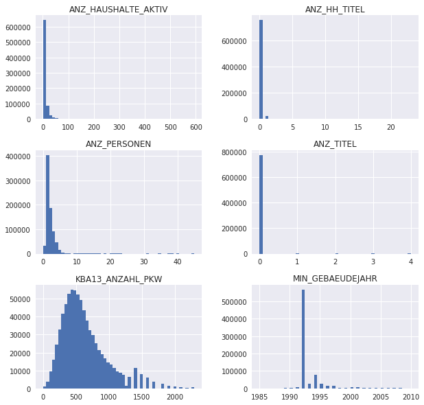

```python
# visualize distribution of values
azdias[numeric_features].astype(np.float).hist(bins=50, figsize=(10, 10))
plt.subplots_adjust(hspace=0.3)
plt.show()
```

```python
# replace 'nan' to np.nan
azdias.replace('nan', np.nan, inplace=True)
```

```python
# missing values in numeric features
azdias[numeric_features].isnull().sum()
```

```
ANZ_PERSONEN              0
ANZ_TITEL                 0
ANZ_HAUSHALTE_AKTIV    5740
ANZ_HH_TITEL           3233
MIN_GEBAEUDEJAHR          0
KBA13_ANZAHL_PKW       5660
dtype: int64
```

```python
# missing values in ordinal features
azdias[ordinal_features].isnull().sum()
```

```
ALTERSKATEGORIE_GROB      2625
FINANZ_MINIMALIST            0
FINANZ_SPARER                0
FINANZ_VORSORGER             0
FINANZ_ANLEGER               0
FINANZ_UNAUFFAELLIGER        0
FINANZ_HAUSBAUER             0
HEALTH_TYP               34524
RETOURTYP_BK_S            3834
SEMIO_SOZ                    0
SEMIO_FAM                    0
SEMIO_REL                    0
SEMIO_MAT                    0
SEMIO_VERT                   0
SEMIO_LUST                   0
SEMIO_ERL                    0
SEMIO_KULT                   0
SEMIO_RAT                    0
SEMIO_KRIT                   0
SEMIO_DOM                    0
SEMIO_KAEM                   0
SEMIO_PFLICHT                0
SEMIO_TRADV                  0
HH_EINKOMMEN_SCORE           0
W_KEIT_KIND_HH           56282
WOHNDAUER_2008               0
KONSUMNAEHE                 51
KBA05_ANTG1              24457
KBA05_ANTG2              24457
KBA05_ANTG3              24457
KBA05_ANTG4              24457
KBA05_GBZ                24457
BALLRAUM                   543
EWDICHTE                   543
INNENSTADT                 543
GEBAEUDETYP_RASTER           5
KKK                      54778
MOBI_REGIO               24457
ONLINE_AFFINITAET         3834
REGIOTYP                 54778
PLZ8_ANTG1                8115
PLZ8_ANTG2                8115
PLZ8_ANTG3                8115
PLZ8_ANTG4                8115
PLZ8_HHZ                  8115
PLZ8_GBZ                  8115
ARBEIT                    3999
ORTSGR_KLS9               3907
RELAT_AB                  3999
dtype: int64
```

```python
# Imputer missing values

from sklearn.preprocessing import Imputer

numeric_imputer = Imputer(missing_values=np.nan, strategy='median', axis=0)
azdias_imputed = pd.DataFrame(numeric_imputer.fit_transform(azdias.astype(np.float)))
azdias_imputed.columns = azdias.columns
```

```python
azdias_imputed.to_csv('azdias_imputed.csv', index=False)
```

```python
azdias_imputed = pd.read_csv('azdias_imputed.csv')
```

```python
# Apply feature scaling to the general population demographics data.

from sklearn.preprocessing import MinMaxScaler

mm_scaler = MinMaxScaler()
azdias_scaled = pd.DataFrame(mm_scaler.fit_transform(azdias_imputed))
azdias_scaled.columns = azdias_imputed.columns
azdias_scaled.head()
```

|  | ALTERSKATEGORIE_GROB | FINANZ_MINIMALIST | FINANZ_SPARER | FINANZ_VORSORGER | FINANZ_ANLEGER | FINANZ_UNAUFFAELLIGER | FINANZ_HAUSBAUER | HEALTH_TYP | RETOURTYP_BK_S | SEMIO_SOZ | ... | PRAEGENDE_JUGENDJAHR_DECADE_1.0 | PRAEGENDE_JUGENDJAHR_DECADE_2.0 | PRAEGENDE_JUGENDJAHR_DECADE_3.0 | PRAEGENDE_JUGENDJAHR_DECADE_4.0 | PRAEGENDE_JUGENDJAHR_DECADE_5.0 | PRAEGENDE_JUGENDJAHR_DECADE_6.0 | CAMEO_INTL_2015_LIFESTAGE | CAMEO_INTL_2015_WEALTH | PLZ8_BAUMAX | WOHNLAGE_NEIGHBORHOOD |
| --- | --- | --- | --- | --- | --- | --- | --- | --- | --- | --- | --- | --- | --- | --- | --- | --- | --- | --- | --- | --- | --- |
| 0 | 0.000000 | 0.00 | 1.00 | 0.25 | 1.00 | 0.75 | 1.00 | 1.0 | 0.00 | 0.666667 | ... | 0.0 | 0.0 | 0.0 | 0.0 | 0.0 | 1.0 | 0.00 | 0.00 | 0.00 | 0.4 |
| 1 | 0.666667 | 0.00 | 0.75 | 0.00 | 0.25 | 0.50 | 1.00 | 1.0 | 0.50 | 0.500000 | ... | 0.0 | 0.0 | 0.0 | 0.0 | 0.0 | 1.0 | 0.75 | 0.75 | 0.00 | 0.8 |
| 2 | 1.000000 | 0.75 | 0.25 | 1.00 | 0.25 | 0.00 | 0.25 | 0.5 | 0.25 | 0.666667 | ... | 0.0 | 0.0 | 0.0 | 1.0 | 0.0 | 0.0 | 0.25 | 1.00 | 0.00 | 0.0 |
| 3 | 0.666667 | 0.75 | 0.50 | 0.75 | 0.00 | 0.50 | 0.25 | 1.0 | 1.00 | 0.833333 | ... | 0.0 | 0.0 | 0.0 | 1.0 | 0.0 | 0.0 | 0.50 | 0.25 | 0.25 | 0.6 |
| 4 | 0.000000 | 0.50 | 0.00 | 1.00 | 0.25 | 0.25 | 1.00 | 1.0 | 0.50 | 0.166667 | ... | 0.0 | 1.0 | 0.0 | 0.0 | 0.0 | 0.0 | 0.75 | 0.00 | 0.00 | 0.0 |

5 rows × 201 columns

```python
azdias_scaled.isnull().sum().sum()
```

```
0
```

### Discussion 2.1: Apply Feature Scaling

As noted above, most of the missing values were removed. We still have some missing values in numeric and ordinal features. There are no missing values in categorical features, since they were handled in feature encoding part.

To impute the remaining missing values, I used 'median' strategy since some of the numeric values are skewed. After imputing, I used MinMaxScaler to scale the features as it doesn't affect the one-hot encoded features.

### Step 2.2: Perform Dimensionality Reduction

On your scaled data, you are now ready to apply dimensionality reduction techniques.

- Use sklearn's [PCA](http://scikit-learn.org/stable/modules/generated/sklearn.decomposition.PCA.html) class to apply principal component analysis on the data, thus finding the vectors of maximal variance in the data. To start, you should not set any parameters (so all components are computed) or set a number of components that is at least half the number of features (so there's enough features to see the general trend in variability).
- Check out the ratio of variance explained by each principal component as well as the cumulative variance explained. Try plotting the cumulative or sequential values using matplotlib's [`plot()`](https://matplotlib.org/api/_as_gen/matplotlib.pyplot.plot.html) function. Based on what you find, select a value for the number of transformed features you'll retain for the clustering part of the project.
- Once you've made a choice for the number of components to keep, make sure you re-fit a PCA instance to perform the decided-on transformation.

```python
# Apply PCA to the data.

from sklearn.decomposition import PCA

pca = PCA()
pca.fit(azdias_scaled)
```

```
PCA(copy=True, iterated_power='auto', n_components=None, random_state=None,
  svd_solver='auto', tol=0.0, whiten=False)
```

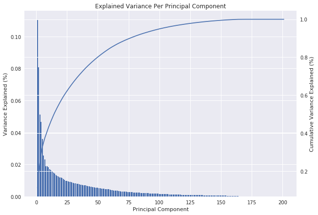

```python
# Investigate the variance accounted for by each principal component.

num_components = len(pca.explained_variance_ratio_)
indx = np.arange(num_components) + 1 # start with 1
variance_ratio = pca.explained_variance_ratio_

plt.figure(figsize=(10, 7))

cumulative_variance_ratio = np.cumsum(variance_ratio)

plt.bar(indx, variance_ratio)
plt.ylabel("Variance Explained (%)")
plt.xlabel("Principal Component")
plt.grid(True)
plt.twinx()

plt.plot(indx, cumulative_variance_ratio)
plt.ylabel("Cumulative Variance Explained (%)")
plt.title('Explained Variance Per Principal Component')
plt.grid(True)

plt.show()
```

```python
num_components
```

```
201
```

```python
# Re-apply PCA to the data while selecting for number of components to retain.

pca = PCA(n_components = 100)
pca.fit(azdias_scaled)
```

```
PCA(copy=True, iterated_power='auto', n_components=100, random_state=None,
  svd_solver='auto', tol=0.0, whiten=False)
```

```python
(201 - 100) / 201 * 100
```

```
50.24875621890548
```

### Discussion 2.2: Perform Dimensionality Reduction

I chose 100 components out of 201 since 95% cumulative variance is explained with these 100 components.

Reduction rate = (201 - 100) / 201 * 100 = 50.2%. Though it is low, the cumulative variancee explained is above 90%.

### Step 2.3: Interpret Principal Components

Now that we have our transformed principal components, it's a nice idea to check out the weight of each variable on the first few components to see if they can be interpreted in some fashion.

As a reminder, each principal component is a unit vector that points in the direction of highest variance (after accounting for the variance captured by earlier principal components). The further a weight is from zero, the more the principal component is in the direction of the corresponding feature. If two features have large weights of the same sign (both positive or both negative), then increases in one tend expect to be associated with increases in the other. To contrast, features with different signs can be expected to show a negative correlation: increases in one variable should result in a decrease in the other.

- To investigate the features, you should map each weight to their corresponding feature name, then sort the features according to weight. The most interesting features for each principal component, then, will be those at the beginning and end of the sorted list. Use the data dictionary document to help you understand these most prominent features, their relationships, and what a positive or negative value on the principal component might indicate.
- You should investigate and interpret feature associations from the first three principal components in this substep. To help facilitate this, you should write a function that you can call at any time to print the sorted list of feature weights, for the *i*-th principal component. This might come in handy in the next step of the project, when you interpret the tendencies of the discovered clusters.

```python
# HINT: Try defining a function here or in a new cell that you can reuse in the
# other cells.

def plot_weights(df, pca, comp_num):

    features, weights = zip(*sorted(zip(df.columns.tolist(), pca.components_[comp_num-1].tolist()), key=lambda x:x[1]))

    df_temp = pd.DataFrame({'Features': features, 'Weights': weights})

    df_temp.plot.barh(x='Features', y='Weights', figsize=(6, 50), grid=True)
    plt.ylabel('Features')
    plt.xlabel('Weights')
    plt.title('Weights for the ' + str(comp_num) + ' th component')
    plt.show()
```

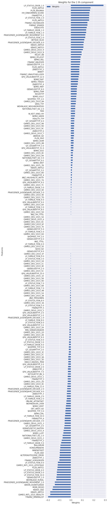

```python
# Map weights for the first principal component to corresponding feature names
# and then print the linked values, sorted by weight.

plot_weights(azdias_scaled, pca, 1)
```

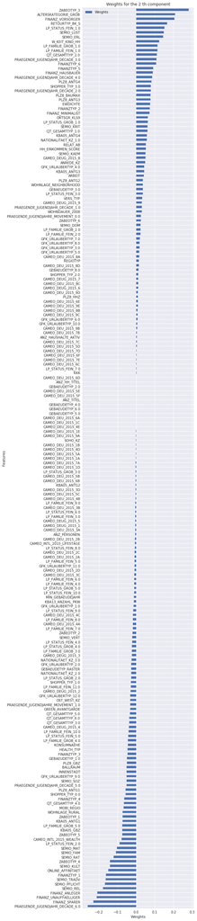

```python
# Map weights for the second principal component to corresponding feature names
# and then print the linked values, sorted by weight.

plot_weights(azdias_scaled, pca, 2)
```

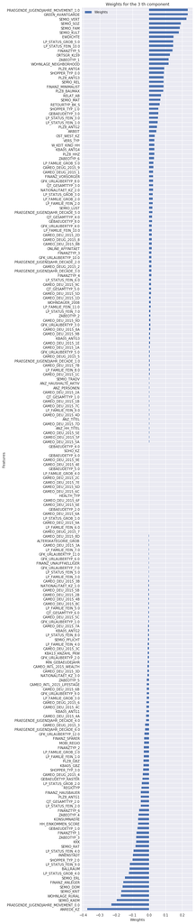

```python
# Map weights for the third principal component to corresponding feature names
# and then print the linked values, sorted by weight.

plot_weights(azdias_scaled, pca, 3)
```

### Discussion 2.3: Interpret Principal Components

**Prominent features in each component (top 3)**

**First component**  
**Positive**

- LP_STATUS_GROB_1.0 - Social status - LOW INCOME
- PLZ8_ANTG4 - Number of 10+ family houses in the PLZ8 region
- PLZ8_BAUMAX - Most common building type within the PLZ8 region
- HH_EINKOMMEN_SCORE - Estimated household net income

**Negative**

- FINANZ_MINIMALIST - Financial typology, low financial interest
- CAMEO_INTL_2015_WEALTH - Wealth Typology
- KBA05_ANTG1 - Number of 1-2 family houses in the microcell

The first component describes the person's wealth (household income, etc..) and their social status.

**Second component**  
**Positive**

- ZABEOTYP_3 - Energy consumption typology, fair supplied
- ALTERSKATEGORIE_GROB - Estimated age based on given name analysis
- FINANZ_VORSORGER - Financial typology, being prepared

**Negative**

- PRAEGENDE_JUGENDJAHR_DECADE_6.0 - Dominating movement of person's youth, decade = 90s
- FINANZ_SPARER - Financial typology, money-saver
- FINANZ_UNAUFFAELLIGER - Financial typology, inconspicuous

The second component describes the person's financial classification, particularly their consumption of money and other resources.

**Third component**  
**Positive**

- PRAEGENDE_JUGENDJAHRE_MOVEMENT_1.0 - Dominating movement of person's youth, Movement = Avantgarde
- GREEN_AVANTGARDE - Membership in environmental sustainability as part of youth
- SEMIO_VERT - Personality typology, dreamful

**Negative**

- ANREDE_KZ - Gender
- PRAEGENDE_JUGENDJAHRE_MOVEMENT_0.0 - Dominating movement of person's youth, Movement = Mainstream
- SEMIO_KAEM - Personality typology, combative attitude

The third component is an interesting one, it describes the person's gender and their personality type.

## Step 3: Clustering

### Step 3.1: Apply Clustering to General Population

You've assessed and cleaned the demographics data, then scaled and transformed them. Now, it's time to see how the data clusters in the principal components space. In this substep, you will apply k-means clustering to the dataset and use the average within-cluster distances from each point to their assigned cluster's centroid to decide on a number of clusters to keep.

- Use sklearn's KMeans class to perform k-means clustering on the PCA-transformed data.
- Then, compute the average difference from each point to its assigned cluster's center. **Hint**: The KMeans object's `.score()` method might be useful here, but note that in sklearn, scores tend to be defined so that larger is better. Try applying it to a small, toy dataset, or use an internet search to help your understanding.
- Perform the above two steps for a number of different cluster counts. You can then see how the average distance decreases with an increasing number of clusters. However, each additional cluster provides a smaller net benefit. Use this fact to select a final number of clusters in which to group the data. **Warning**: because of the large size of the dataset, it can take a long time for the algorithm to resolve. The more clusters to fit, the longer the algorithm will take. You should test for cluster counts through at least 10 clusters to get the full picture, but you shouldn't need to test for a number of clusters above about 30.
- Once you've selected a final number of clusters to use, re-fit a KMeans instance to perform the clustering operation. Make sure that you also obtain the cluster assignments for the general demographics data, since you'll be using them in the final Step 3.3.

```python
from sklearn.cluster import KMeans
```

```python
X_transformed = pca.transform(azdias_scaled)
```

```python
# Over a number of different cluster counts...
models = []
for i in range(1, 11):
    models.append(KMeans(n_clusters=i))

# run k-means clustering on the data and...

for model in models:
    model.fit(X_transformed)

# compute the average within-cluster distances.
scores = []
for model in models:
    scores.append(np.abs(model.score(X_transformed)))
```

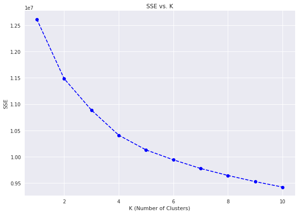

```python
# Investigate the change in within-cluster distance across number of clusters.
# HINT: Use matplotlib's plot function to visualize this relationship.

plt.figure(figsize=(10, 7))
plt.plot(range(1, 11), scores, linestyle='--', marker='o', color='b')
plt.xlabel('K (Number of Clusters)')
plt.ylabel('SSE')
plt.title('SSE vs. K')
plt.grid(True)
plt.show()
```

```python
# Re-fit the k-means model with the selected number of clusters and obtain
# cluster predictions for the general population demographics data.

model= KMeans(n_clusters=4)
model_population = model.fit(X_transformed)
```

### Discussion 3.1: Apply Clustering to General Population

Using Elbow method, the **optimal number of clusters is 4**. After that point, the decrease in SSE is low.

The elbow method is subjective and there is no single answer. Here, 4 clusters seems to be an optimal choice.

### Step 3.2: Apply All Steps to the Customer Data

Now that you have clusters and cluster centers for the general population, it's time to see how the customer data maps on to those clusters. Take care to not confuse this for re-fitting all of the models to the customer data. Instead, you're going to use the fits from the general population to clean, transform, and cluster the customer data. In the last step of the project, you will interpret how the general population fits apply to the customer data.

- Don't forget when loading in the customers data, that it is semicolon (`;`) delimited.
- Apply the same feature wrangling, selection, and engineering steps to the customer demographics using the `clean_data()` function you created earlier. (You can assume that the customer demographics data has similar meaning behind missing data patterns as the general demographics data.)
- Use the sklearn objects from the general demographics data, and apply their transformations to the customers data. That is, you should not be using a `.fit()` or `.fit_transform()` method to re-fit the old objects, nor should you be creating new sklearn objects! Carry the data through the feature scaling, PCA, and clustering steps, obtaining cluster assignments for all of the data in the customer demographics data.

```python
# Load in the customer demographics data.
customers = pd.read_csv('Udacity_CUSTOMERS_Subset.csv', sep=';')
print('Udacity_CUSTOMERS_Subset')
print('{} rows and {} columns'.format(customers.shape[0], customers.shape[1]))
display(customers.head(5))
```

```
Udacity_CUSTOMERS_Subset
191652 rows and 85 columns
```

|  | AGER_TYP | ALTERSKATEGORIE_GROB | ANREDE_KZ | CJT_GESAMTTYP | FINANZ_MINIMALIST | FINANZ_SPARER | FINANZ_VORSORGER | FINANZ_ANLEGER | FINANZ_UNAUFFAELLIGER | FINANZ_HAUSBAUER | ... | PLZ8_ANTG1 | PLZ8_ANTG2 | PLZ8_ANTG3 | PLZ8_ANTG4 | PLZ8_BAUMAX | PLZ8_HHZ | PLZ8_GBZ | ARBEIT | ORTSGR_KLS9 | RELAT_AB |
| --- | --- | --- | --- | --- | --- | --- | --- | --- | --- | --- | --- | --- | --- | --- | --- | --- | --- | --- | --- | --- | --- |
| 0 | 2 | 4 | 1 | 5.0 | 5 | 1 | 5 | 1 | 2 | 2 | ... | 3.0 | 3.0 | 1.0 | 0.0 | 1.0 | 5.0 | 5.0 | 1.0 | 2.0 | 1.0 |
| 1 | -1 | 4 | 1 | NaN | 5 | 1 | 5 | 1 | 3 | 2 | ... | NaN | NaN | NaN | NaN | NaN | NaN | NaN | NaN | NaN | NaN |
| 2 | -1 | 4 | 2 | 2.0 | 5 | 1 | 5 | 1 | 4 | 4 | ... | 2.0 | 3.0 | 3.0 | 1.0 | 3.0 | 3.0 | 2.0 | 3.0 | 5.0 | 3.0 |
| 3 | 1 | 4 | 1 | 2.0 | 5 | 1 | 5 | 2 | 1 | 2 | ... | 3.0 | 2.0 | 1.0 | 0.0 | 1.0 | 3.0 | 4.0 | 1.0 | 3.0 | 1.0 |
| 4 | -1 | 3 | 1 | 6.0 | 3 | 1 | 4 | 4 | 5 | 2 | ... | 2.0 | 4.0 | 2.0 | 1.0 | 2.0 | 3.0 | 3.0 | 3.0 | 5.0 | 1.0 |

5 rows × 85 columns

```python
# Apply preprocessing, feature transformation, and clustering from the general
# demographics onto the customer data, obtaining cluster predictions for the
# customer demographics data.

customers, customers_outliers = clean_data(customers, feat_info)

customers.shape
```

```
(139068, 200)
```

```python
# One feature value is missing customers data
for col in azdias.columns:
    if col not in customers.columns:
        print(col)
```

```
GEBAEUDETYP_5.0
```

```python
feat_info[feat_info['attribute']=='GEBAEUDETYP']
```

|  | attribute | information_level | type | missing_or_unknown |
| --- | --- | --- | --- | --- |
| 52 | GEBAEUDETYP | building | categorical | -1,0 |

```python
# adding a dummy column with all zeros
list_GEBAEUDETYP_5 = list(np.zeros(customers.shape[0]))
GEBAEUDETYP_5 = pd.Series(list_GEBAEUDETYP_5)
```

```python
customers['GEBAEUDETYP_5.0'] = GEBAEUDETYP_5
customers_outliers['GEBAEUDETYP_5.0'] = GEBAEUDETYP_5
```

```python
customers.shape
```

```
(139068, 201)
```

```python
# Apply feature transformation, and clustering from the general
# demographics onto the customer data, obtaining cluster predictions for the
# customer demographics data.

customers_imputed = pd.DataFrame(numeric_imputer.transform(customers.astype(np.float)))
customers_imputed.columns = customers.columns

customers_scaled = pd.DataFrame(mm_scaler.transform(customers_imputed))
customers_scaled.columns = customers_imputed.columns

customers_transformed = pca.transform(customers_scaled)
```

```python
population_clusters = pd.DataFrame({'cluster': model_population.predict(X_transformed)})
customer_clusters = pd.DataFrame({'cluster': model_population.predict(customers_transformed)})
```

### Step 3.3: Compare Customer Data to Demographics Data

At this point, you have clustered data based on demographics of the general population of Germany, and seen how the customer data for a mail-order sales company maps onto those demographic clusters. In this final substep, you will compare the two cluster distributions to see where the strongest customer base for the company is.

Consider the proportion of persons in each cluster for the general population, and the proportions for the customers. If we think the company's customer base to be universal, then the cluster assignment proportions should be fairly similar between the two. If there are only particular segments of the population that are interested in the company's products, then we should see a mismatch from one to the other. If there is a higher proportion of persons in a cluster for the customer data compared to the general population (e.g. 5% of persons are assigned to a cluster for the general population, but 15% of the customer data is closest to that cluster's centroid) then that suggests the people in that cluster to be a target audience for the company. On the other hand, the proportion of the data in a cluster being larger in the general population than the customer data (e.g. only 2% of customers closest to a population centroid that captures 6% of the data) suggests that group of persons to be outside of the target demographics.

Take a look at the following points in this step:

- Compute the proportion of data points in each cluster for the general population and the customer data. Visualizations will be useful here: both for the individual dataset proportions, but also to visualize the ratios in cluster representation between groups. Seaborn's [`countplot()`](https://seaborn.pydata.org/generated/seaborn.countplot.html) or [`barplot()`](https://seaborn.pydata.org/generated/seaborn.barplot.html) function could be handy.
  - Recall the analysis you performed in step 1.1.3 of the project, where you separated out certain data points from the dataset if they had more than a specified threshold of missing values. If you found that this group was qualitatively different from the main bulk of the data, you should treat this as an additional data cluster in this analysis. Make sure that you account for the number of data points in this subset, for both the general population and customer datasets, when making your computations!
- Which cluster or clusters are overrepresented in the customer dataset compared to the general population? Select at least one such cluster and infer what kind of people might be represented by that cluster. Use the principal component interpretations from step 2.3 or look at additional components to help you make this inference. Alternatively, you can use the `.inverse_transform()` method of the PCA and StandardScaler objects to transform centroids back to the original data space and interpret the retrieved values directly.
- Perform a similar investigation for the underrepresented clusters. Which cluster or clusters are underrepresented in the customer dataset compared to the general population, and what kinds of people are typified by these clusters?

```python
# Compare the proportion of data in each cluster for the customer data to the
# proportion of data in each cluster for the general population.
```

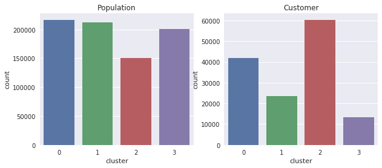

```python
# What kinds of people are part of a cluster that is overrepresented in the
# customer data compared to the general population?

plt.figure(figsize=(10, 4))

plt.subplot(1, 2, 1)
plt.title('Population')
sns.countplot(x=population_clusters['cluster'])

plt.subplot(1, 2, 2)
plt.title('Customer')
sns.countplot(x=customer_clusters['cluster'])

plt.show()
```

```python
# What kinds of people are part of a cluster that is underrepresented in the
# customer data compared to the general population?

# Underrepresented in the customer data
under_represented = pd.DataFrame(pca.inverse_transform(X_transformed[population_clusters[population_clusters['cluster'] == 3].index, :]))
under_represented.columns = azdias_scaled.columns

# Top 3 positive and negative features in the first componet
under_represented[['LP_STATUS_GROB_1.0', 'PLZ8_ANTG4', 'PLZ8_BAUMAX', 'FINANZ_MINIMALIST', 'CAMEO_INTL_2015_WEALTH', 'KBA05_ANTG1']].head()
```

|  | LP_STATUS_GROB_1.0 | PLZ8_ANTG4 | PLZ8_BAUMAX | FINANZ_MINIMALIST | CAMEO_INTL_2015_WEALTH | KBA05_ANTG1 |
| --- | --- | --- | --- | --- | --- | --- |
| 0 | 0.978487 | 0.518003 | 0.052384 | -0.118838 | -0.002121 | -0.029684 |
| 1 | 0.969366 | -0.014683 | 0.049730 | 0.072651 | 0.760880 | 0.797941 |
| 2 | -0.035356 | 0.524508 | 0.133637 | 0.147327 | 0.492819 | 0.164003 |
| 3 | 0.015901 | 0.533540 | -0.066461 | 0.418574 | 0.767573 | 0.522775 |
| 4 | 0.015899 | 0.908344 | 0.750912 | 0.742373 | 0.020548 | 0.259220 |

```python
# Overrepresented in the customer data
over_represented = pd.DataFrame(pca.inverse_transform(X_transformed[population_clusters[population_clusters['cluster'] == 2].index, :]))
over_represented.columns = azdias_scaled.columns

# Top 3 positive and negative features in the first componet
over_represented[['LP_STATUS_GROB_1.0', 'PLZ8_ANTG4', 'PLZ8_BAUMAX', 'FINANZ_MINIMALIST', 'CAMEO_INTL_2015_WEALTH', 'KBA05_ANTG1']].head()
```

|  | LP_STATUS_GROB_1.0 | PLZ8_ANTG4 | PLZ8_BAUMAX | FINANZ_MINIMALIST | CAMEO_INTL_2015_WEALTH | KBA05_ANTG1 |
| --- | --- | --- | --- | --- | --- | --- |
| 0 | 0.057729 | -0.014934 | 0.012316 | 0.167082 | 0.767649 | 0.272176 |
| 1 | 0.056939 | 0.485084 | -0.029324 | 0.739855 | 1.023172 | 0.295617 |
| 2 | 0.012526 | 0.464775 | 0.086975 | 0.159352 | 0.972429 | 0.282772 |
| 3 | -0.002340 | 0.464226 | 0.265456 | 1.023926 | 0.479134 | 0.321999 |
| 4 | -0.017579 | 0.406912 | 0.213136 | 0.684135 | 0.781638 | 0.184711 |

```python
def compare_data(col):
    plt.figure(figsize=(15, 4))
    plt.subplot(1, 2, 1)
    plt.title('Popular')
    plt.xlabel(col)
    over_represented[col].hist(bins=50)
    plt.subplot(1, 2, 2)
    plt.title('Unpopular')
    plt.xlabel(col)
    under_represented[col].hist(bins=50)
    plt.show()
```

```python
prominent_cols = ['LP_STATUS_GROB_1.0', 'PLZ8_ANTG4', 'PLZ8_BAUMAX', 'FINANZ_MINIMALIST',
                  'CAMEO_INTL_2015_WEALTH', 'KBA05_ANTG1']
```

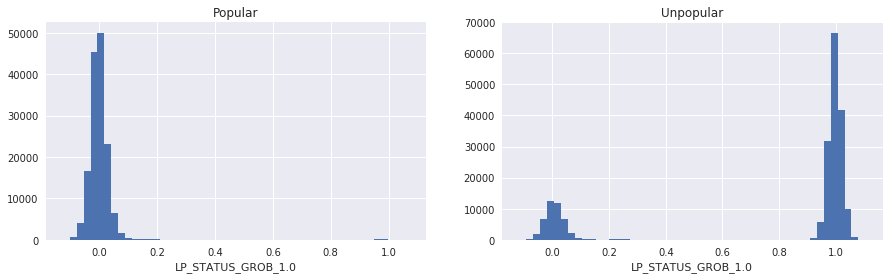

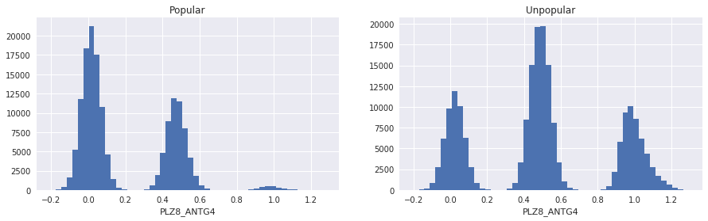

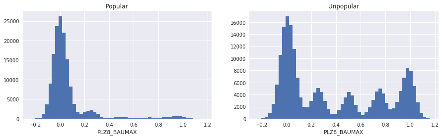

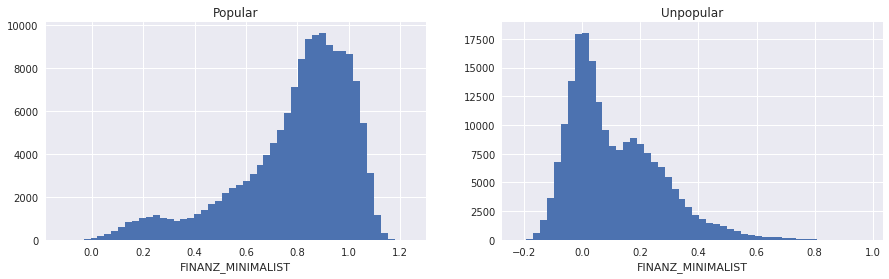

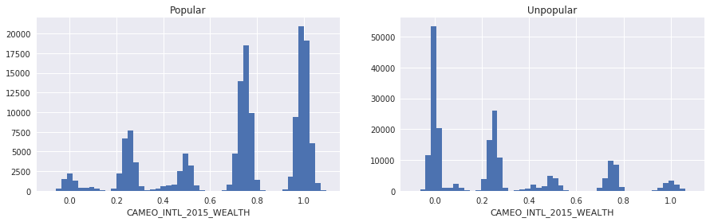

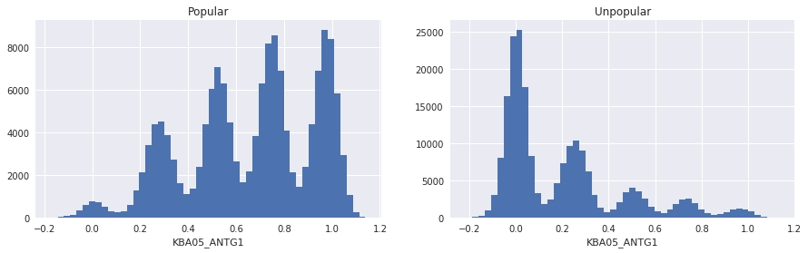

```python
for col in prominent_cols:
    compare_data(col)
```

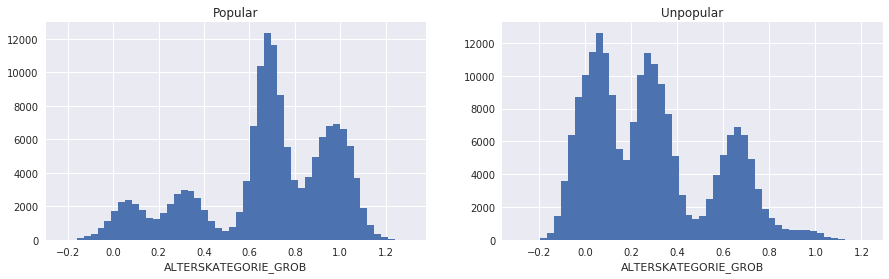

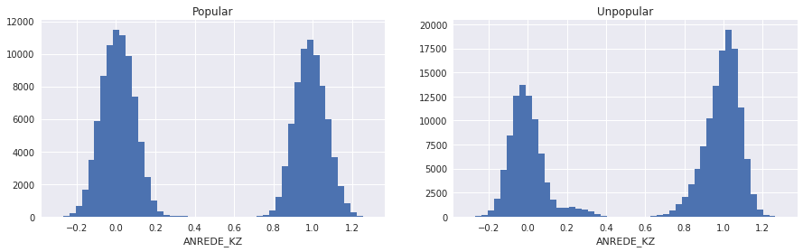

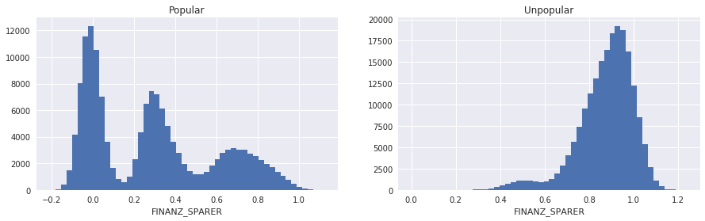

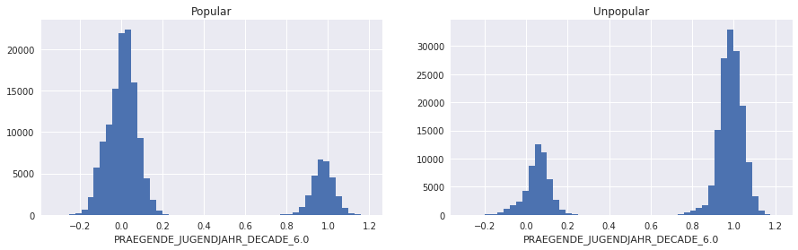

```python
# lets look at more interesting features
interesting_cols = ['ALTERSKATEGORIE_GROB','ANREDE_KZ','FINANZ_SPARER','PRAEGENDE_JUGENDJAHR_DECADE_6.0']

for col in interesting_cols:
    compare_data(col)
```

### Discussion 3.3: Compare Customer Data to Demographics Data

Lets look at the prominent features of the **First component** that describes the person's wealth (household income, etc..) and their social status and some more interesting features from the second and third components.

For these features, the following characterstics are shown by the popular and unpopular segments in the population.

[output not shown]

From this, we can conclude that the mail-order sales company is popular among older people who are relatively weathly. They also have a lower financial interest with less money saving tendency. They tend to live in regions where 1-2 family houses are higher in number.

> Congratulations on making it this far in the project! Before you finish, make sure to check through the entire notebook from top to bottom to make sure that your analysis follows a logical flow and all of your findings are documented in **Discussion** cells. Once you've checked over all of your work, you should export the notebook as an HTML document to submit for evaluation. You can do this from the menu, navigating to **File -> Download as -> HTML (.html)**. You will submit both that document and this notebook for your project submission.